# IMPORTANT INFORMATION

文档名: Chess.csv  
文档内有什么信息: position in the world classific, name, elo points, date (when was this recorded), age  
文档有什么特殊的地方:

#### 到底研究的主题是什么：

- the average elo rating of each year -> line
- the average chess supergrandmasters' age of more years -> line
- the number of surnames which start with a certain letter -> pie

#### 画图的预测:

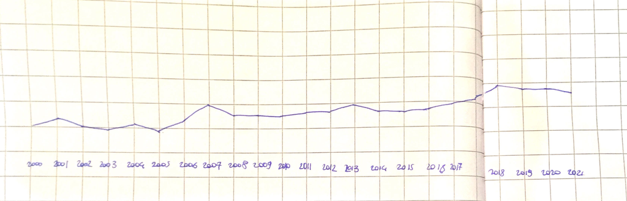

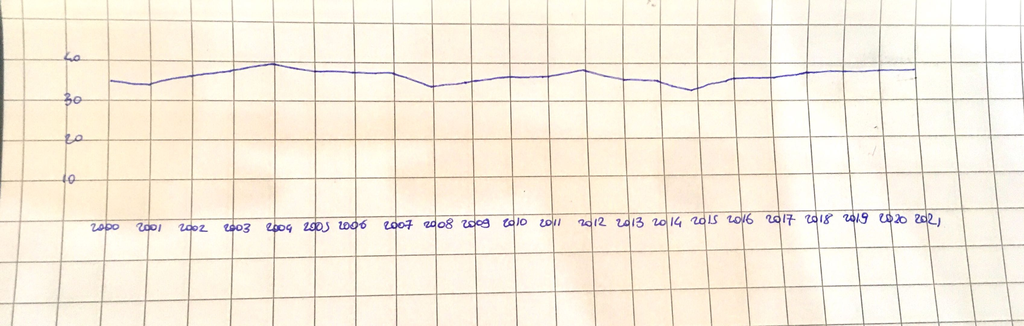

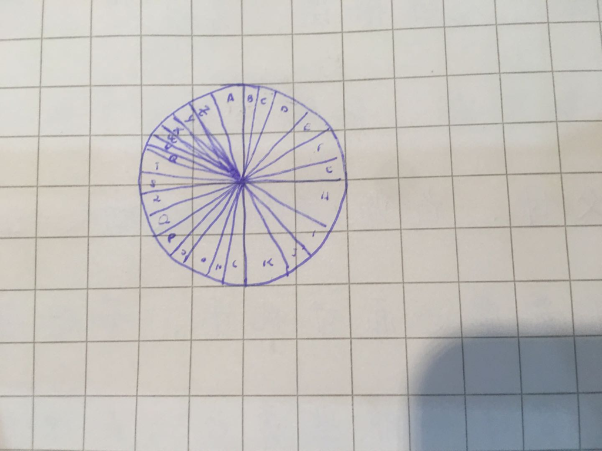

```python
from cs103 import *
from typing import NamedTuple, List
import csv
import matplotlib.pyplot as plt
import numpy as np
```

## DATA DEFINITION

```python
#data definition



ClassificPosition = int  # in range[1, 20]
#interpretation: the Classific position
#examples
cp1 = 1
cp2 = 9
cp3 = 20
@typecheck
#template based on atomic non distinct
def fn_for_classific_position(cp:ClassificPosition)->...:
    return ...,(cp)



EloRating = int # in range[0, ...)
#interpretation: the Elo rating
#examples
er1 = 0
er2 = 546
er3 = 2864
@typecheck
#template based on atomic non distinct
def fn_for_elo_rating(er:EloRating)->...:
    return ...,(er)



Age = int #in range[0, ...)
#interpretation: the age of a person
#examples
a1 = 0
a2 = 29
a3 = 65
@typecheck
#template based on atomic non distinct
def fn_for_age(a:Age)->...:
    return ...,(a)


Year = int #in range[1000, 9999]
#interpretation: the possible years
#examples
y1 = 1000
y2 = 2021
y3 = 9999
@typecheck
#template based on atomic non distinct
def fn_for_year(yyyy:Year)->...:
    return ...,(yyyy)


ChessPlayer = NamedTuple("ChessPlayer", [("position", ClassificPosition),
                                       ("surname", str),
                                       ("elo", EloRating),
                                       ("date", str),
                                       ("age", Age)])
#interpretation: the information of a chess player in a precise date
#examples
#TEST 1    File: Chess Test1.csv
Carlsen2010 = ChessPlayer(1, "Carlsen", 2810, "2010 Jan", 19)
Carlsen2011 = ChessPlayer(1, "Carlsen", 2814, "2011 Jan", 20)
Carlsen2012 = ChessPlayer(1, "Carlsen", 2835, "2012 Jan", 21)
Carlsen2013 = ChessPlayer(1, "Carlsen", 2861, "2013 Jan", 22)
Carlsen2014 = ChessPlayer(1, "Carlsen", 2872, "2014 Jan", 23)
Carlsen2015 = ChessPlayer(1, "Carlsen", 2862, "2015 Jan", 24)
Carlsen2016 = ChessPlayer(1, "Carlsen", 2844, "2016 Jan", 25)
Carlsen2017 = ChessPlayer(1, "Carlsen", 2840, "2017 Jan", 26)
Carlsen2018 = ChessPlayer(1, "Carlsen", 2834, "2018 Jan", 27)
Carlsen2019 = ChessPlayer(1, "Carlsen", 2835, "2019 Jan", 28)
Carlsen2020 = ChessPlayer(1, "Carlsen", 2872, "2020 Jan", 29)
Carlsen2021 = ChessPlayer(1, "Carlsen", 2862, "2021 Jan", 30)
#TEST 2    File: Chess Test2.csv
Caruana2021 = ChessPlayer(2,"Caruana",2823,"2021 Jan",28)
DinLiRen2021 = ChessPlayer(3,"Ding Liren",2791,"2021 Jan",28)
Nepomniachtchi2021 = ChessPlayer(4,"Nepomniachtchi",2789,"2021 Jan",30)
So2021 = ChessPlayer(9,"So",2770,"2021 Jan",27)
Giri2021 = ChessPlayer(11,"Giri",2764,"2021 Jan",26)
Karjakin2021 = ChessPlayer(15,"Karjakin",2757,"2021 Jan",30)
Anand2021 = ChessPlayer(16,"Anand",2753,"2021 Jan",51)
Firouzja2021 = ChessPlayer(18,"Firouzja",2749,"2021 Jan",17)
Nakamura2021 = ChessPlayer(20,"Nakamura",2736,"2021 Jan",33)
#TEST 3    File: Chess Test3.csv
VachierLagrave2021 = ChessPlayer(5,"Vachier-Lagrave",2784,"2021 Jan",30)
Aronian2020 = ChessPlayer(6,"Aronian",2773,"2020 Jan",37)
Nakamura2019 = ChessPlayer(16,"Nakamura",2749,"2019 Jan",31)
DinLiRen2017 = ChessPlayer(14,"Ding Liren",2760,"2017 Jan",24)
Kramnik2016 = ChessPlayer(2,"Kramnik",2801,"2016 Jan",40)
Caruana2013 = ChessPlayer(5,"Caruana",2781,"2013 Jan",20)
Topalov2008 = ChessPlayer(3,"Topalov",2780,"2008 Jan",32)
Topalov2007 = ChessPlayer(1,"Topalov",2783,"2007 Jan",31)
PolgarJ2003 = ChessPlayer(13,"Polgar J",2700,"2003 Jan",26)
Karpov2003 = ChessPlayer(20,"Karpov",2688,"2003 Jan",51)
Kasparov2000 = ChessPlayer(1,"Kasparov",2851,"2000 Jan",36)
@typecheck
#template based on compound
def fn_for_chess_player(cp:ChessPlayer)->...:
    return ...,(fn_for_classific_position(cp.position),
                cp.name,
                fn_for_elo_rating(cp.elo),
                cp.date,
                fn_for_age(cp.age))


AllChessPlayersInfo = List[ChessPlayer]
#interpretation: all the information about super chess players
#examples
lacpiN = []
lacpi1 = [Carlsen2021, Carlsen2020, Carlsen2019, Carlsen2018, Carlsen2017, Carlsen2016, Carlsen2015, Carlsen2014,
          Carlsen2013, Carlsen2012, Carlsen2011, Carlsen2010]
lacpi2 = [Caruana2021, DinLiRen2021, Nepomniachtchi2021, So2021, Giri2021, Karjakin2021, Anand2021, Firouzja2021,
          Nakamura2021]
lacpi3 = [VachierLagrave2021, Aronian2020, Nakamura2019, DinLiRen2017, Kramnik2016, Caruana2013, Topalov2008, Topalov2007,
         PolgarJ2003, Karpov2003, Kasparov2000]
@typecheck
#template based on arbitrary sized
def fn_for_all_chess_players_info(lacpi:AllChessPlayersInfo)->...:
    #definition for acc.
    acc = ...    # type = ...
    for cp in lacpi:
        acc = ...,(fn_for_chess_player(cp), acc)
    return ...,(acc)



#List[int]
#interpretation: a list of int
#examples
loin = []
loi1 = [-8, 0, 67]
loi2 = [-956, 4, 823]
@typecheck
#template based on arbitrary sized
def fn_for_loi(loi:List[int])->...:
    #definition for acc.
    acc = ...    # type = ...
    for i in loi:
        acc = ...,(i, acc)
    return ...,(acc)

#List[float]
#interpretation: a list of float
#examples
lofn = []
lof1 = [-8.9, 0, 54.89]
lof2 = [-956.0, 4.344, 823.098]
@typecheck
#template based on arbitrary sized
def fn_for_lof(lof:List[float])->...:
    #definition for acc.
    acc = ...    # type = ...
    for f in lof:
        acc = ...,(f, acc)
    return ...,(acc)

#List[str]
#interpretation: a list of str
#examples
losn = []
los1 = [-8.9, 0, 54.89]
los2 = [-956.0, 4.344, 823.098]
@typecheck
#template based on arbitrary sized
def fn_for_los(los:List[float])->...:
    #definition for acc.
    acc = ...    # type = ...
    for s in los:
        acc = ...,(s, acc)
    return ...,(acc)



AverageElo = NamedTuple("AverageElo", [("year", Year),
                                     ("elo", EloRating)])
#interpretation: the average elo rating of an year
#examples
me1 = AverageElo(2021, 4305)
me2 = AverageElo(2000, 2764)
me3 = AverageElo(2011, 2786)
@typecheck
#template based on compound
def fn_for_average_elo(me:AverageElo)->...:
    return ...,(fn_for_year(me.year),
                fn_for_elo_rating(me.elo))
#List[AverageElo]
#interpretation: list of medium elo
#examples
lome1 = []
lome2 = [me1]
lome3 = [me2, me3]
@typecheck
#template based on arbitrary sized
def fn_for_lome(lome:List[AverageElo])->...:
    #definition for acc.
    acc = ...   # type = ...
    for me in lome:
        acc = ...,(acc, fn_for_average_elo(me))
    return ...,(acc)



AverageAge = NamedTuple("AverageAge", [("year", Year),
                                       ("age", Age)])
#interpretation: the average age of an year
#examples
aa1 = AverageAge(2000, 28)
aa2 = AverageAge(2011, 55)
aa3 = AverageAge(2021, 29)
@typecheck
#template based on compound
def fn_for_average_age(aa:AverageAge)->...:
    return ...,(aa.year,
                aa.age)

#List[AverageAge]
#interpretation: List of Average ages
#examples
laa1 = []
laa2 = [aa1]
laa3 = [aa2, aa3]
@typecheck
#template based on arbitrary sized
def fn_for_laa(laa:List[AverageAge])->...:
    #definition for acc.
    acc = ...    # type = ...
    for aa in laa:
        acc = ...,(acc, fn_for_average_age(aa))

Percentage = float   # in range [0, 100]
#interpretation: the percentage
#examples:
p1 = 0.0
p2 = 100.0
p3 = 54.28
@typecheck
#template based on atomic non distinct
def fn_for_percentage(p:Percentage)->...:
    return ...,(p)

StartingLetterPercentage = NamedTuple("StartingLetterPercentage", [("letter", str),
                                                                   ("percentage", Percentage)])
#interpretation: the starting letter percentage
#examples
slp1 = StartingLetterPercentage("C", 4.2)
slp2 = StartingLetterPercentage("G", 97.0)
slp3 = StartingLetterPercentage("N", 61.6777)
@typecheck
#template based on compound
def fn_for_starting_letter_percentage(slp:StartingLetterPercentage)->...:
    return ...,(slp.letter,
                fn_for_percentage(slp.percentage))

#List[StartingLetterPercentage]
#interpretation: list of StartingLetterPercentage
#examples
loslp1 = []
loslp2 = [slp1]
loslp3 = [slp2, slp3]
@typecheck
#template based on arbitrary sized
def fn_for_loslp(loslp:List[StartingLetterPercentage])->...:
    # definition for acc.
    acc = ...   # type = ...
    for slp in loslp:
        acc = ...,(acc, fn_for_starting_letter_percentage(slp))
    return ...,(acc)
```

## READ FUNCTION

```python
@typecheck
def chess_file_read(filename:str)-> AllChessPlayersInfo:
    """
    read chess informations in a csv file

    """
    #return []
    #template from AllChessPlayerInfo
    #acc. contains the result
    acc = []    #type = AllChessPlayerInfo
    with open(filename) as ChessFile:
        FileInfo = csv.reader(ChessFile)
        next(FileInfo)

        for r in FileInfo:
            cp = ChessPlayer(parse_int(r[0]), r[1], parse_int(r[2]), r[3], parse_int(r[4]))
            acc.append(cp)
    return acc
#TEST
start_testing()
expect(chess_file_read("Chess Test1.csv"), lacpi1)
expect(chess_file_read("Chess Test2.csv"), lacpi2)
expect(chess_file_read("Chess Test3.csv"), lacpi3)
summary()
```

```
3 of 3 tests passed
```

## AVERAGE (helper function)

```python
@typecheck
def average(loi:List[int])->float:
    """
    Enter a List of ints
    Return the average number

    """
    #return 0.0
    #template from List[int]
    #acc. contains the sum of all ints
    acc = 0   # type = int
    for i in loi:
        acc = acc + i
    return acc/((len(loi) == 0) * 1 + len(loi))
#TEST
start_testing()
expect(average([]), 0)
expect(average([0, 2, -1]), 1/3)
expect(average([50, 50, 50]), 50)
expect(average([-563, 54, 300]), -69.66666666666667)
summary()
```

```
4 of 4 tests passed
```

## AVERAGE ELO RATING EACH YEAR

HELPER FUNCTIONS

```python
@typecheck
def find_chess_players_of_an_year(lacpi:AllChessPlayersInfo, year:Year)->AllChessPlayersInfo:
    """
    Enter AllChessPlayerInfo and the wanted year
    Return the chess players of the selected year

    """
    #return []
    #template from AllChessPlayerInfo
    #acc. contains the result
    acc = []    # type = AllChessPlayerInfo
    for cp in lacpi:
        if int(cp.date[0:4]) == year:
            acc.append(cp)
    return acc

#TEST
start_testing()
expect(find_chess_players_of_an_year(lacpi1, 2021), [Carlsen2021])
expect(find_chess_players_of_an_year(lacpi2, 2021), lacpi2)
expect(find_chess_players_of_an_year(lacpi3, 2000), [Kasparov2000])
summary()




@typecheck
def to_elo_list(lacpi:AllChessPlayersInfo)->List[int]:
    """
    Enter AllChessPlayerInfo
    Return the all the ratings as a List[int]

    """
    #return []
    #template from AllChessPlayerInfo
    #acc. contains the result
    acc = []    # type = AllChessPlayerInfo
    for cp in lacpi:
        acc.append(cp.elo)
    return acc
#TEST
start_testing()
expect(to_elo_list([Carlsen2021]), [Carlsen2021.elo])
expect(to_elo_list([Carlsen2018]), [Carlsen2018.elo])
expect(to_elo_list([Carlsen2013]), [Carlsen2013.elo])
summary()




@typecheck
def delete_all_of_year(lacpi:AllChessPlayersInfo, year:Year)->AllChessPlayersInfo:
    """
    Enter AllChessPlayerInfo
    Return the AllChessPlayerInfo without the once of that year

    """
    #return []
    #template from AllChessPlayerInfo
    #acc. contains the result
    acc = []    # type = AllChessPlayerInfo
    for cp in lacpi:
        if int(cp.date[0:4]) != year:
            acc.append(cp)
    return acc
#TEST
start_testing()
expect(delete_all_of_year([Carlsen2021], 2021), [])
expect(delete_all_of_year(lacpi2, 2021), [])
expect(delete_all_of_year(lacpi3, 2000), [VachierLagrave2021, Aronian2020, Nakamura2019, DinLiRen2017, Kramnik2016, Caruana2013, Topalov2008, Topalov2007,
                                          PolgarJ2003, Karpov2003])
summary()



@typecheck
def average_elo_each_year(lacpi:AllChessPlayersInfo)->List[AverageElo]:
    """
    Enter AllChessPlayerInfo
    Return the average elo for each year

    """
    #return []
    #template from AllChessPlayerInfo
    #acc. contains the result
    if len(lacpi) == 0:
        return []

    year = int(lacpi[0].date[:4])
    acc = []    # type = List[float]
    while len(lacpi) != 0:
        year = int(lacpi[0].date[:4])
        year_list = find_chess_players_of_an_year(lacpi, year)
        acc.append(AverageElo(year, average(to_elo_list(year_list))))
        lacpi = delete_all_of_year(lacpi, year)
    return acc
#TEST
start_testing()
expect(average_elo_each_year(lacpi1), [AverageElo(year=2021, elo=2862.0),
                                       AverageElo(year=2020, elo=2872.0),
                                       AverageElo(year=2019, elo=2835.0),
                                       AverageElo(year=2018, elo=2834.0),
                                       AverageElo(year=2017, elo=2840.0),
                                       AverageElo(year=2016, elo=2844.0),
                                       AverageElo(year=2015, elo=2862.0),
                                       AverageElo(year=2014, elo=2872.0),
                                       AverageElo(year=2013, elo=2861.0),
                                       AverageElo(year=2012, elo=2835.0),
                                       AverageElo(year=2011, elo=2814.0),
                                       AverageElo(year=2010, elo=2810.0)])
expect(average_elo_each_year(lacpi2), [AverageElo(year=2021, elo=2770.222222222222)])
expect(average_elo_each_year(lacpi3), [AverageElo(year=2021, elo=2784.0),
                                       AverageElo(year=2020, elo=2773.0),
                                       AverageElo(year=2019, elo=2749.0),
                                       AverageElo(year=2017, elo=2760.0),
                                       AverageElo(year=2016, elo=2801.0),
                                       AverageElo(year=2013, elo=2781.0),
                                       AverageElo(year=2008, elo=2780.0),
                                       AverageElo(year=2007, elo=2783.0),
                                       AverageElo(year=2003, elo=2694.0),
                                       AverageElo(year=2000, elo=2851.0)])
summary()
```

```
3 of 3 tests passed
3 of 3 tests passed
3 of 3 tests passed
3 of 3 tests passed
```

```python
@typecheck
def chess_average_ratings_analyze(filename:str)->List[AverageElo]:
    """
    Enter a filename
    Return all the average elo in this file

    """
    #return []
    #return ...,(filename)
    return average_elo_each_year(chess_file_read(filename))
```

```python
@typecheck
def xp(lae:List[AverageElo])->List[float]:
    """
    find x point

    """
    #return []
    #template from List[float]
    #acc. contains the result
    acc = []    # type = List[float]
    for ae in lae:
        acc.append(ae.year)
    return acc
#TEST
start_testing()
expect(xp([]), [])
expect(xp(lome2), [2021])
expect(xp(lome3), [2000, 2011])
summary()


@typecheck
def yp(lae:List[AverageElo])->List[float]:
    """
    Find y point

    """
    #return []
    #template from List[float]
    #acc. contains the result
    acc = []    # type = List[float]
    for ae in lae:
        acc.append(ae.elo)
    return acc
#TEST
start_testing()
expect(yp([]), [])
expect(yp(lome2), [4305])
expect(yp(lome3), [2764, 2786])
summary()
```

```
3 of 3 tests passed
3 of 3 tests passed
```

```python
@typecheck
def elo_rating_label_out(lacpi:AllChessPlayersInfo)->None:
    """
    Enter a chess csv file
    Print the chart

    """
    loae = average_elo_each_year(lacpi)
    xpoint = np.array(xp(loae))
    ypoint = np.array(yp(loae))
    font = {'family':'Kunstler Script','color':'#000000','size':50}
    plt.title("Average Elo Points", fontdict = font)
    plt.plot(xpoint, ypoint, c = "lime", linestyle = "dashed")
    plt.xlabel("YEAR")
    plt.ylabel("ELO RATING")
    plt.show()
```

MAIN FUNCTION

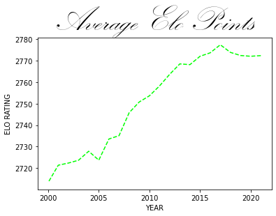

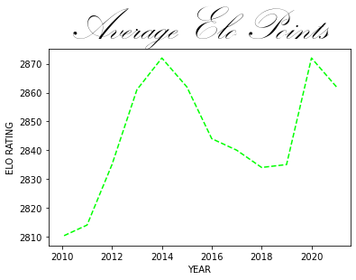

[figure not shown]

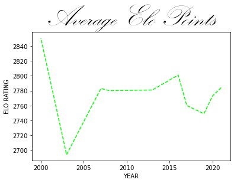

```
4 of 4 tests passed
```

```python
@typecheck
def main(filename:str)->None:
    """
    Enter a filename
    Return all the average elo in this file

    """
    #return []
    #return ...,(filename)
    return elo_rating_label_out(chess_file_read(filename))

#TEST
start_testing()
expect(main("Chess.csv"), None)
expect(main("Chess Test1.csv"), None)
expect(main("Chess Test2.csv"), None)
expect(main("Chess Test3.csv"), None)
summary()
```

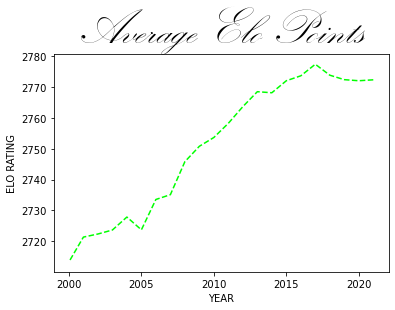

```python
main("Chess.csv")
```

## AVERAGE AGE EACH YEAR

HELPER FUNCTION

```python
@typecheck
def find_chess_players_of_an_year(lacpi:AllChessPlayersInfo, year:Year)->AllChessPlayersInfo:
    """
    Enter AllChessPlayerInfo and the wanted year
    Return the chess players of the selected year

    """
    #return []
    #template from AllChessPlayerInfo
    #acc. contains the result
    acc = []    # type = AllChessPlayerInfo
    for cp in lacpi:
        if int(cp.date[0:4]) == year:
            acc.append(cp)
    return acc

#TEST
start_testing()
expect(find_chess_players_of_an_year(lacpi1, 2021), [Carlsen2021])
expect(find_chess_players_of_an_year(lacpi2, 2021), lacpi2)
expect(find_chess_players_of_an_year(lacpi3, 2000), [Kasparov2000])
summary()



@typecheck
def delete_all_of_year(lacpi:AllChessPlayersInfo, year:Year)->AllChessPlayersInfo:
    """
    Enter AllChessPlayerInfo
    Return the AllChessPlayerInfo without the once of that year

    """
    #return []
    #template from AllChessPlayerInfo
    #acc. contains the result
    acc = []    # type = AllChessPlayerInfo
    for cp in lacpi:
        if int(cp.date[0:4]) != year:
            acc.append(cp)
    return acc
#TEST
start_testing()
expect(delete_all_of_year([Carlsen2021], 2021), [])
expect(delete_all_of_year(lacpi2, 2021), [])
expect(delete_all_of_year(lacpi3, 2000), [VachierLagrave2021, Aronian2020, Nakamura2019, DinLiRen2017, Kramnik2016, Caruana2013, Topalov2008, Topalov2007,
                                          PolgarJ2003, Karpov2003])
summary()



@typecheck
def to_age_list(lacpi:AllChessPlayersInfo)->List[int]:
    """
    Enter AllChessPlayerInfo
    Return the all the ratings as a List[int]

    """
    #return []
    #template from AllChessPlayerInfo
    #acc. contains the result
    acc = []    # type = AllChessPlayerInfo
    for cp in lacpi:
        acc.append(cp.age)
    return acc
#TEST
start_testing()
expect(to_age_list([Carlsen2021]), [Carlsen2021.age])
expect(to_age_list([Carlsen2018]), [Carlsen2018.age])
expect(to_age_list([Carlsen2013]), [Carlsen2013.age])
summary()



@typecheck
def average_age_each_year(lacpi:AllChessPlayersInfo)->List[AverageAge]:
    """
    Enter AllChessPlayerInfo
    Return the average elo for each year

    """
    #return []
    #template from AllChessPlayerInfo
    #acc. contains the result
    if len(lacpi) == 0:
        return []

    year = int(lacpi[0].date[:4])
    acc = []    # type = List[float]
    while len(lacpi) != 0:
        year = int(lacpi[0].date[:4])
        year_list = find_chess_players_of_an_year(lacpi, year)
        acc.append(AverageAge(year, average(to_age_list(year_list))))
        lacpi = delete_all_of_year(lacpi, year)
    return acc

#TEST
start_testing()
expect(average_age_each_year(lacpi1), [AverageAge(year=2021, age=30.0),
                                       AverageAge(year=2020, age=29.0),
                                       AverageAge(year=2019, age=28.0),
                                       AverageAge(year=2018, age=27.0),
                                       AverageAge(year=2017, age=26.0),
                                       AverageAge(year=2016, age=25.0),
                                       AverageAge(year=2015, age=24.0),
                                       AverageAge(year=2014, age=23.0),
                                       AverageAge(year=2013, age=22.0),
                                       AverageAge(year=2012, age=21.0),
                                       AverageAge(year=2011, age=20.0),
                                       AverageAge(year=2010, age=19.0)])
expect(average_age_each_year(lacpi2), [AverageAge(year=2021, age=30.0)])
expect(average_age_each_year(lacpi3), [AverageAge(year=2021, age=30.0),
                                       AverageAge(year=2020, age=37.0),
                                       AverageAge(year=2019, age=31.0),
                                       AverageAge(year=2017, age=24.0),
                                       AverageAge(year=2016, age=40.0),
                                       AverageAge(year=2013, age=20.0),
                                       AverageAge(year=2008, age=32.0),
                                       AverageAge(year=2007, age=31.0),
                                       AverageAge(year=2003, age=38.5),
                                       AverageAge(year=2000, age=36.0)])
summary()
```

```
3 of 3 tests passed
3 of 3 tests passed
3 of 3 tests passed
3 of 3 tests passed
```

```python
@typecheck
def xp(laa:List[AverageAge])->List[float]:
    """
    find x point

    """
    #return []
    #template from List[float]
    #acc. contains the result
    acc = []    # type = List[float]
    for aa in laa:
        acc.append(aa.year)
    return acc
#TEST
start_testing()
expect(xp([]), [])
expect(xp(laa2), [2000])
expect(xp(laa3), [2011, 2021])
summary()

@typecheck
def yp(laa:List[AverageAge])->List[float]:
    """
    Find y point

    """
    #return []
    #template from List[float]
    #acc. contains the result
    acc = []    # type = List[float]
    for aa in laa:
        acc.append(aa.age)
    return acc
#TEST
start_testing()
expect(yp([]), [])
expect(yp(laa2), [28])
expect(yp(laa3), [55, 29])
summary()
```

```
3 of 3 tests passed
3 of 3 tests passed
```

```python
@typecheck
def age_average_label_out(lacpi:AllChessPlayersInfo)->None:
    """
    Enter a chess csv file
    Print the chart

    """
    laoe = average_age_each_year(lacpi)
    xpoint = np.array(xp(laoe))
    ypoint = np.array(yp(laoe))
    font = {'family':'Kunstler Script','color':'#000000','size':50}
    plt.title("Average Age", fontdict = font)
    plt.plot(xpoint, ypoint, c = "lime", linestyle = "dashed")
    plt.xlabel("YEAR")
    plt.ylabel("PLAYER AGE")
    plt.show()
```

MAIN FUNCTION

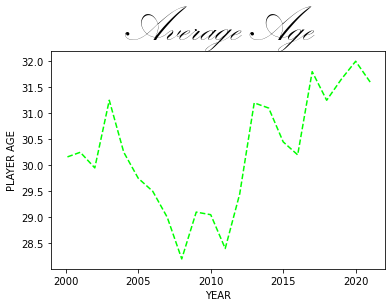

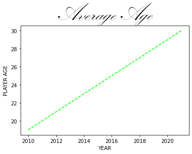

[figure not shown]

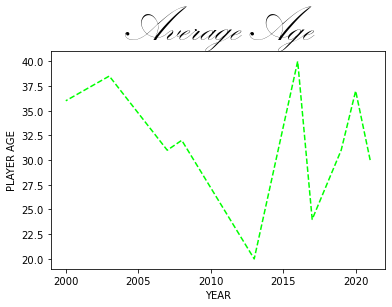

```
4 of 4 tests passed
```

```python
@typecheck
def main(filename:str)->None:
    """
    Enter a filename
    Return all the average age in this file

    """
    #return []
    #return ...,(filename)
    return age_average_label_out(chess_file_read(filename))
#TEST
start_testing()
expect(main("Chess.csv"), None)
expect(main("Chess Test1.csv"), None)
expect(main("Chess Test2.csv"), None)
expect(main("Chess Test3.csv"), None)
summary()
```

## NAME STARTING LETTER

HELPER FUNCTIONS

```python
@typecheck
def names_only(lacpi:AllChessPlayersInfo)->List[str]:
    """
    Enter AllChessPlayerInfo
    Return A List of of all the chess players names

    """
    #return []
    #template from ALlChessPlayersInfo
    #acc. contains the result
    acc = []   # type = List[str]
    for cp in lacpi:
        AlreadyExist = False
        for n in acc:
            if n == cp.surname:
                AlreadyExist = True
                break
        if not(AlreadyExist):
            acc.append(cp.surname)
    return acc

#TEST
start_testing()
expect(names_only(lacpi1), ["Carlsen"])
expect(names_only([Kasparov2000]), ["Kasparov"])
expect(names_only([Anand2021]), ["Anand"])
summary()


@typecheck
def starting_letter_only(names:List[str])->List[str]:
    """
    Enter some names
    Return their first letter

    """
    #return []
    #template from List[str]
    #acc. contains the result
    acc = []    # type = List[str]
    for n in names:
        if len(n) != 0:
            acc.append(n[0])
        else:
            acc.append("")
    return acc

#TEST
start_testing()
expect(starting_letter_only(["Carlsen", "Caruana"]), ["C", "C"])
expect(starting_letter_only([]), [])
expect(starting_letter_only(["Anand", "Kasparov"]), ["A", "K"])
summary()


@typecheck
def percentage(i:int, tot:int)->Percentage:
    """
    Enter the number of the tot

    """
    #return 0
    #return ...,(i, tot)
    return i/tot * 100
#TEST
start_testing()
expect(percentage(1, 2), 50)
expect(percentage(1, 5), 20)
expect(percentage(1, 8), 12.5)
summary()


@typecheck
def delete_all_of_letter(los:List[str], l:str)->List[str]:
    """
    Enter A list of letters and a letter
    Return the List without that letter

    """
    #return []
    #template from List[str]
    #acc. contains the result
    acc = []    # type = List[str]
    for letter in los:
        if letter != l:
            acc.append(letter)
    return acc
#TEST
start_testing()
expect(delete_all_of_letter(["s", "a"], "s"), ["a"])
expect(delete_all_of_letter([], "s"), [])
expect(delete_all_of_letter(["f", "a"], "s"), ["f", "a"])
summary()


@typecheck
def number_of_letters(los:List[str], l:str)->int:
    """
    Enter a list of letters and a letter
    Return the number of it in the list

    """
    #return 0
    #template from List[str]
    #acc. contains the result
    acc = 0    # type = int
    for letter in los:
        if letter == l:
            acc += 1
    return acc
#TEST
start_testing()
expect(number_of_letters(["s", "a", "s"], "s"), 2)
expect(number_of_letters([], "s"), 0)
expect(number_of_letters(["sd", "a", ""], "s"), 0)
summary()


@typecheck
def starting_letter_percentage(lacpi:AllChessPlayersInfo)->List[StartingLetterPercentage]:
    """
    Enter a AllChessPlayerInfo
    Return its player Starting letters percentage

    """
    #return []
    #return ...
    #acc. contains the result
    OnlyStartingLetters = starting_letter_only(names_only(lacpi))
    LettersN = len(OnlyStartingLetters)
    acc = []    # type = List[StartingLetterPercentage]
    while len(OnlyStartingLetters) != 0:
        if len(OnlyStartingLetters[0]) == 0:
            OnlyStartingLetters = delete_all_of_letter(OnlyStartingLetters, "")
        else:
            acc.append(StartingLetterPercentage(OnlyStartingLetters[0], percentage(number_of_letters(OnlyStartingLetters, OnlyStartingLetters[0]), LettersN)))
            OnlyStartingLetters = delete_all_of_letter(OnlyStartingLetters, OnlyStartingLetters[0])

    return acc

#TEST
start_testing()
expect(starting_letter_percentage([]), [])
expect(starting_letter_percentage(lacpi1), [StartingLetterPercentage(letter='C', percentage=100.0)])
expect(starting_letter_percentage(lacpi2), [StartingLetterPercentage(letter='C', percentage=11.11111111111111),
                                            StartingLetterPercentage(letter='D', percentage=11.11111111111111),
                                            StartingLetterPercentage(letter='N', percentage=22.22222222222222),
                                            StartingLetterPercentage(letter='S', percentage=11.11111111111111),
                                            StartingLetterPercentage(letter='G', percentage=11.11111111111111),
                                            StartingLetterPercentage(letter='K', percentage=11.11111111111111),
                                            StartingLetterPercentage(letter='A', percentage=11.11111111111111),
                                            StartingLetterPercentage(letter='F', percentage=11.11111111111111)])

expect(starting_letter_percentage(lacpi3), [StartingLetterPercentage(letter='V', percentage=10.0),
                                            StartingLetterPercentage(letter='A', percentage=10.0),
                                            StartingLetterPercentage(letter='N', percentage=10.0),
                                            StartingLetterPercentage(letter='D', percentage=10.0),
                                            StartingLetterPercentage(letter='K', percentage=30.0),
                                            StartingLetterPercentage(letter='C', percentage=10.0),
                                            StartingLetterPercentage(letter='T', percentage=10.0),
                                            StartingLetterPercentage(letter='P', percentage=10.0)])
summary()
```

```
3 of 3 tests passed
3 of 3 tests passed
3 of 3 tests passed
3 of 3 tests passed
3 of 3 tests passed
4 of 4 tests passed
```

```python
@typecheck
def percentage_list(loslp:List[StartingLetterPercentage])->List[float]:
    """
    Enter a StartingLetterPercentage list
    Return the Percentages

    """
    #return []
    #template from List[StartingLetterPercentage]
    #acc contains the result
    acc = []    #type = List[float]
    for slp in loslp:
        acc.append(slp.percentage)
    return acc
#TEST
start_testing()
expect(percentage_list([StartingLetterPercentage(letter='C', percentage=100.0)]), [100.0])
expect(percentage_list([StartingLetterPercentage(letter='V', percentage=10.0),
                        StartingLetterPercentage(letter='A', percentage=10.0),
                        StartingLetterPercentage(letter='N', percentage=10.0),
                        StartingLetterPercentage(letter='D', percentage=10.0),
                        StartingLetterPercentage(letter='K', percentage=30.0),
                        StartingLetterPercentage(letter='C', percentage=10.0),
                        StartingLetterPercentage(letter='T', percentage=10.0),
                        StartingLetterPercentage(letter='P', percentage=10.0)]), [10, 10, 10, 10, 30, 10, 10, 10])
expect(percentage_list([]), [])
summary()


@typecheck
def letter_list(loslp:List[StartingLetterPercentage])->List[str]:
    """
    Enter a StartingLetterPercentage list
    Return all its letters

    """
    #return []
    #template from List[StartingLetterPercentage]
    #acc contains the result
    acc = []    #type = List[float]
    for slp in loslp:
        acc.append(slp.letter)
    return acc
#TEST
start_testing()
expect(letter_list([StartingLetterPercentage(letter='C', percentage=100.0)]), ["C"])
expect(letter_list([StartingLetterPercentage(letter='C', percentage=11.11111111111111),
                    StartingLetterPercentage(letter='D', percentage=11.11111111111111),
                    StartingLetterPercentage(letter='N', percentage=22.22222222222222),
                    StartingLetterPercentage(letter='S', percentage=11.11111111111111),
                    StartingLetterPercentage(letter='G', percentage=11.11111111111111),
                    StartingLetterPercentage(letter='K', percentage=11.11111111111111),
                    StartingLetterPercentage(letter='A', percentage=11.11111111111111),
                    StartingLetterPercentage(letter='F', percentage=11.11111111111111)]), ["C", "D", "N", "S", "G", "K", "A", "F"])
expect(letter_list([]), [])
summary()


@typecheck
def alternate_colors(i:int)->List[str]:
    """
    Enter the number of split
    Return the colors

    """
    #return []
    #return ...,(i)
    colors = ["black", "silver", "lime", "blue", "red", "yellow"]
    acc = []
    remaining = i
    while remaining != 0:
        remaining += -1
        acc.append(colors[remaining % len(colors)])
    if len(acc) % len(colors) == 1:
        acc.remove(acc[-1])
        acc.append(colors[round(len(colors)/2)])

    return acc

#TEST
start_testing()
expect(alternate_colors(7), ['yellow', 'red', 'blue', 'lime', 'silver', 'black', 'blue'])
expect(alternate_colors(0), [])
expect(alternate_colors(4), ['blue', 'lime', 'silver', 'black'])
summary()
```

```
3 of 3 tests passed
3 of 3 tests passed
3 of 3 tests passed
```

```python
@typecheck
def age_average_label_out(lacpi:AllChessPlayersInfo)->None:
    """
    Enter a chess csv file
    Print the chart

    """
    loae = starting_letter_percentage(lacpi)
    split = np.array(percentage_list(loae))
    label = np.array(letter_list(loae))
    ccolors = alternate_colors(len(split))
    font = {'family':'Kunstler Script','color':'#000000','size':50}
    plt.title("Starting Letter Frequency", fontdict = font)
    plt.pie(split, labels = label, colors = ccolors)
    plt.show()
```

MAIN

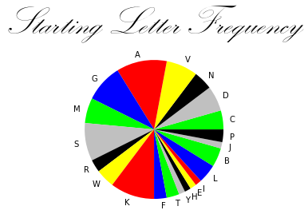

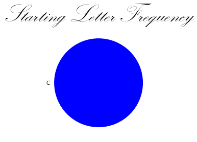

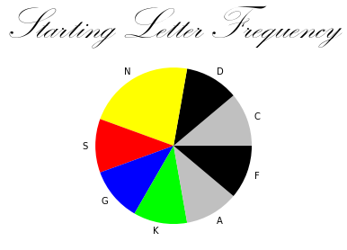

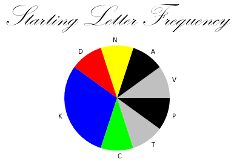

```
4 of 4 tests passed
```

```python
@typecheck
def main(filename:str)->None:
    """
    Enter a filename
    Return the startingLetterPercentages list

    """
    #return []
    #return ...,(filename)
    return age_average_label_out(chess_file_read(filename))

#TEST
start_testing()
expect(main("Chess.csv"), None)
expect(main("Chess Test1.csv"), None)
expect(main("Chess Test2.csv"), None)
expect(main("Chess Test3.csv"), None)
summary()
```